# Insight into the NBA: examining team & player similarities through cluster analysis

Trevor Maggart

February 22, 2022

[figure not shown]

*John Fisher/Getty Images*

```r
knitr::opts_chunk$set(echo = TRUE, message = FALSE, warning = FALSE, fig.align='center')

library(tidyverse)
library(janitor)
library(here)
# Packages for cluster analysis:
library(NbClust)
library(cluster)
library(factoextra)
library(dendextend)
library(ggdendro)
library(stringr)
```

## Ball is life

Basketball is constantly evolving. Where the big man once dominated the post, today the game is dominated by efficient 3-point shooting. Yet still, players like Giannis Antentokounmpo show the game can still be changed.

Below I use **hierarchical agglomerative clustering (HAC)** to find similarities across NBA teams, as well as the top 30 players based on minutes played per game. To determine these clusters, I use the following *per game* parameters: `age`, field goals made (`fg`), field goals attempted (`fga`), three-pointers made (`x3p`), three-pointers attempted (`x3pa`), two-pointers made (`x2p`), two-pointers attempted (`x2pa`), free throws made (`ft`), free throws attempted (`fta`), offensive rebounds (`orb`), defensive rebounds (`drb`), assists (`ast`), steals (`stl`), blocks (`blk`), turnovers (`trv`), personal fouls (`pf`), and points (`pts`).

The data was downloaded from Kaggle and scraped by user Vivo Vinco from Basketball Reference (https://www.basketball-reference.com/leagues/NBA_2022_per_game.html).

```r
# Read in the 'water chemistry' data
nba_teams <- read_csv(here('data','nba.csv')) %>%
  clean_names() %>% # convert to lowercase
  select(-rk,-player,-g,-gs,-mp,-pos,-fg_percent,-x3p_percent,-x2p_percent,-ft_percent,-e_fg_percent,-trb) %>%
  na_if(-999)

# Create a summary dataframe
nba_teams_sum <- nba_teams %>%
  group_by(tm) %>%
  summarize(age_mean = mean(age, na.rm = T),
            fg_mean = mean(fg, na.rm = T),
            fga_mean = mean(fga, na.rm = T),
            x3p_mean = mean(x3p, na.rm = T),
            x3pa_mean = mean(x3pa, na.rm = T),
            x2p_mean = mean(x2p, na.rm = T),
            x2pa_mean = mean(x2pa, na.rm = T),
            orb_mean = mean(orb, na.rm = T),
            ft_mean = mean(ft, na.rm = T),
            fta_mean = mean(fta, na.rm = T),
            drb_mean = mean(drb, na.rm = T),
            ast_mean = mean(ast, na.rm = T),
            stl_mean = mean(stl, na.rm = T),
            blk_mean = mean(blk, na.rm = T),
            tov_mean = mean(tov, na.rm = T),
            pf_mean = mean(pf, na.rm = T),
            pts_mean = mean(pts, na.rm = T))

nba_teams_scale <- nba_teams_sum %>%
  select(-tm) %>%
  scale()

rownames(nba_teams_scale) <- nba_teams_sum$tm
```

## Team Analysis

The following analysis will use **hierarchical agglomerative clustering (HAC)** to determine clusters for teams in the NBA. Clustering will be based on **euclidean distance** measurements. Both a complete linkage and single linkage dendrogram will be presented, as well as a subsequent tanglegram to compare the two.

### Complete Linkage Dendrogram

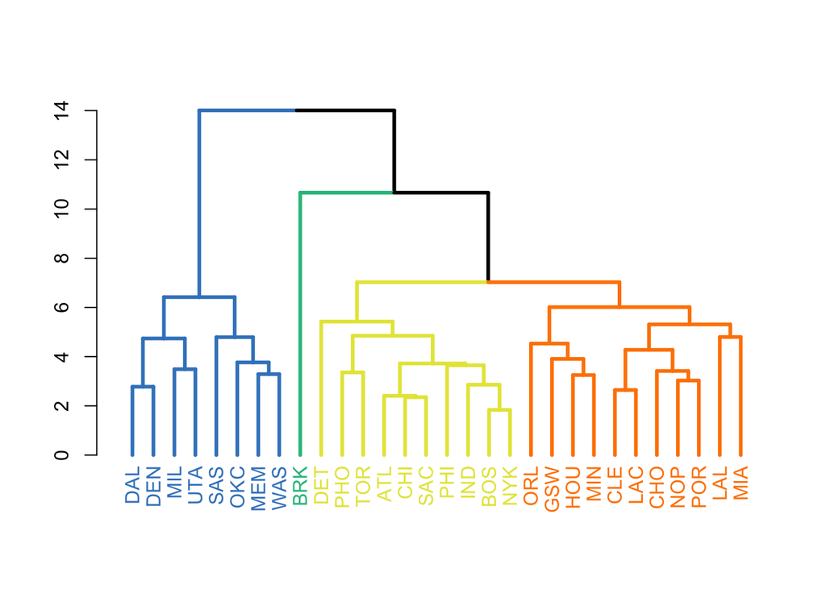

```r
# Calculating the Euclidian matrix
nba_teams_dist <- dist(nba_teams_scale, method = 'euclidean')

# Hierarchical clustering (complete linkage)
nba_teams_hc_complete <- hclust(nba_teams_dist, method = "complete")

# converting to a dendrogram
nba_teams_hc_complete %>%
  as.dendrogram() -> nba_teams_hc_dend_complete # Store as dendrogram

# Visualizing the complete linkage dendrogram
nba_teams_hc_dend_complete %>%
  set("labels_col", value = c("#3d85c6", "#29be8a", "#e5e544","#ff8400"), k=4) %>%
  set("branches_k_color", value = c("#3d85c6", "#29be8a", "#e5e544","#ff8400"), k = 4) %>%
  set("branches_lwd", 3) %>%
  plot(horiz=FALSE, axes=TRUE)
abline(v = 350, lty = 5)
```

### Single Linkage Dendrogram

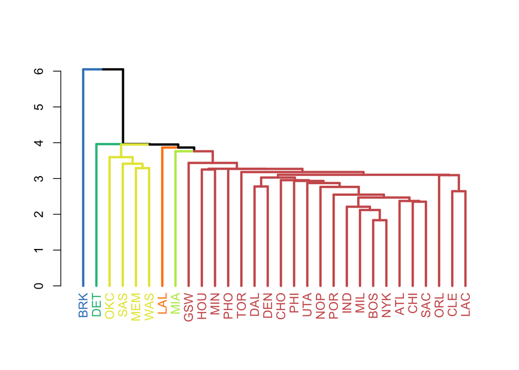

```r
# Hierarchical clustering (single linkage)
nba_teams_hc_single <- hclust(nba_teams_dist, method = "single" )

# converting to a dendrogram
nba_teams_hc_single %>%
  as.dendrogram() -> nba_teams_hc_dend_single # Store as dendrogram

# Visualizing the complete linkage dendrogram
nba_teams_hc_dend_single %>%
  set("labels_col", value = c("#3d85c6", "#29be8a", "#e5e544","#ff8400","#bce954", "indianred"), k=6) %>%
  set("branches_k_color", value = c("#3d85c6", "#29be8a", "#e5e544","#ff8400","#bce954","indianred"), k = 6) %>%
  set("branches_lwd", 3) %>%
  plot(horiz=FALSE, axes=TRUE)
abline(v = 350, lty = 5)
```

### Tanglegram

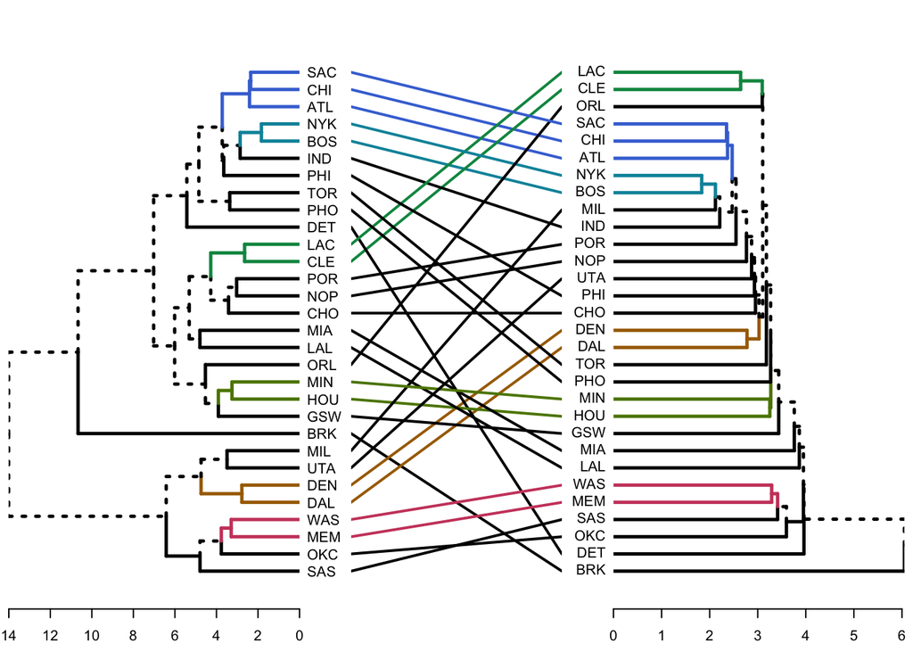

```r
dendlist(nba_teams_hc_dend_complete, nba_teams_hc_dend_single) %>%
  untangle(method = "step1side") %>% # Find the best alignment layout
  tanglegram(common_subtrees_color_branches = TRUE, lwd = 2.0, edge.lwd = 2.5) # Adjust the aesthetics
```

**Figure 1c.** A tanglegram visualizing the relationship between the complete linkage and single linkage dendrograms. Similar cluster results are tied together with lines. Strong clusters are emphasized with color.

```r
# Read in the 'water chemistry' data
nba_player <- read_csv(here('data','nba.csv')) %>%
  clean_names() %>% # convert to lowercase
  select(-rk,-tm,-g,-gs,-pos,-fg_percent,-x3p_percent,-x2p_percent,-ft_percent,-e_fg_percent,-trb) %>%
  na_if(-999) %>%
  slice_max(order_by = mp, n = 30) %>%
  select(-mp)

# Create a summary dataframe
nba_player_sum <- nba_player %>%
  group_by(player) %>%
  summarize(age_mean = mean(age, na.rm = T),
            fg_mean = mean(fg, na.rm = T),
            fga_mean = mean(fga, na.rm = T),
            x3p_mean = mean(x3p, na.rm = T),
            x3pa_mean = mean(x3pa, na.rm = T),
            x2p_mean = mean(x2p, na.rm = T),
            x2pa_mean = mean(x2pa, na.rm = T),
            orb_mean = mean(orb, na.rm = T),
            ft_mean = mean(ft, na.rm = T),
            fta_mean = mean(fta, na.rm = T),
            drb_mean = mean(drb, na.rm = T),
            ast_mean = mean(ast, na.rm = T),
            stl_mean = mean(stl, na.rm = T),
            blk_mean = mean(blk, na.rm = T),
            tov_mean = mean(tov, na.rm = T),
            pf_mean = mean(pf, na.rm = T),
            pts_mean = mean(pts, na.rm = T))

nba_player_scale <- nba_player_sum %>%
  select(-player) %>%
  scale()

rownames(nba_player_scale) <- nba_player_sum$player
```

## Player Analysis (top 30 players by minutes played)

The following analysis will use **hierarchical agglomerative clustering (HAC)** to determine clusters for the top 30 players in the NBA by average minutes played per game. Clustering will be based on **euclidean distance** measurements. Both a complete linkage and single linkage dendrogram will be presented, as well as a subsequent tanglegram to compare the two.

### Complete Linkage Dendrogram

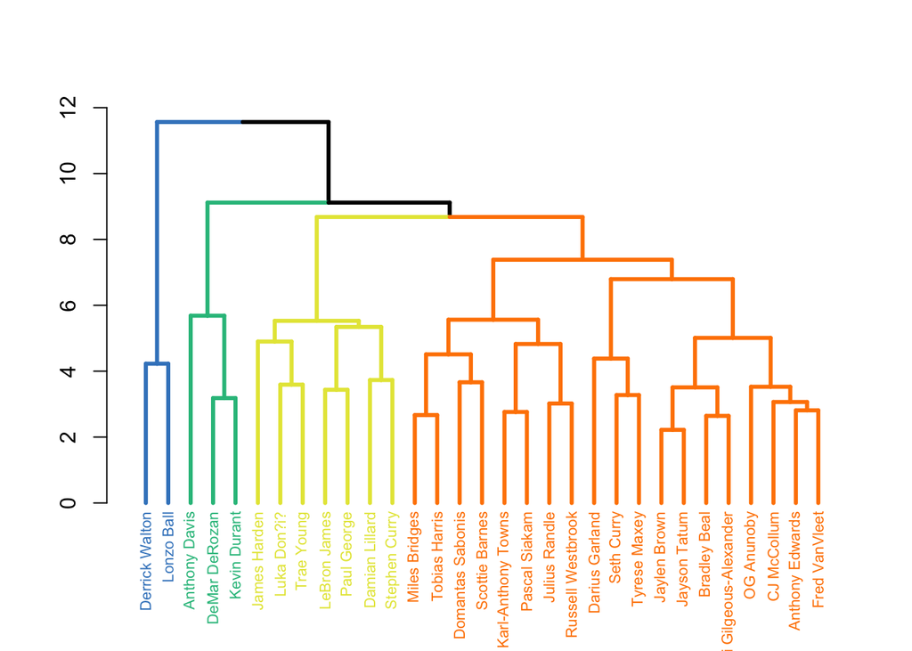

```r
# Calculating the Euclidian matrix
nba_player_dist <- dist(nba_player_scale, method = 'euclidean')

# Hierarchical clustering (complete linkage)
nba_player_hc_complete <- hclust(nba_player_dist, method = "complete")

# converting to a dendrogram
nba_player_hc_complete %>%
  as.dendrogram() -> nba_player_hc_dend_complete # Store as dendrogram

# Visualizing the complete linkage dendrogram
nba_player_hc_dend_complete %>%
  set("labels_col", value = c("#3d85c6", "#29be8a", "#e5e544","#ff8400"), k=4) %>%
  set("branches_k_color", value = c("#3d85c6", "#29be8a", "#e5e544","#ff8400"), k = 4) %>%
  set("branches_lwd", 3) %>%
  set("labels_cex", 0.7) %>%
  plot(horiz=FALSE, axes=TRUE)
abline(v = 350, lty = 5)
```

**Figure 2a.** A complete linkage dendrogram visualizing hierarchical agglomerative clustering based on euclidean distance measurements. The graphic shows clustering results for the top 30 players by average minutes played per game. Multivariate clusters are ordered by color. Y-axis represents distance and the x-axis represents players.

### Single Linkage Dendrogram

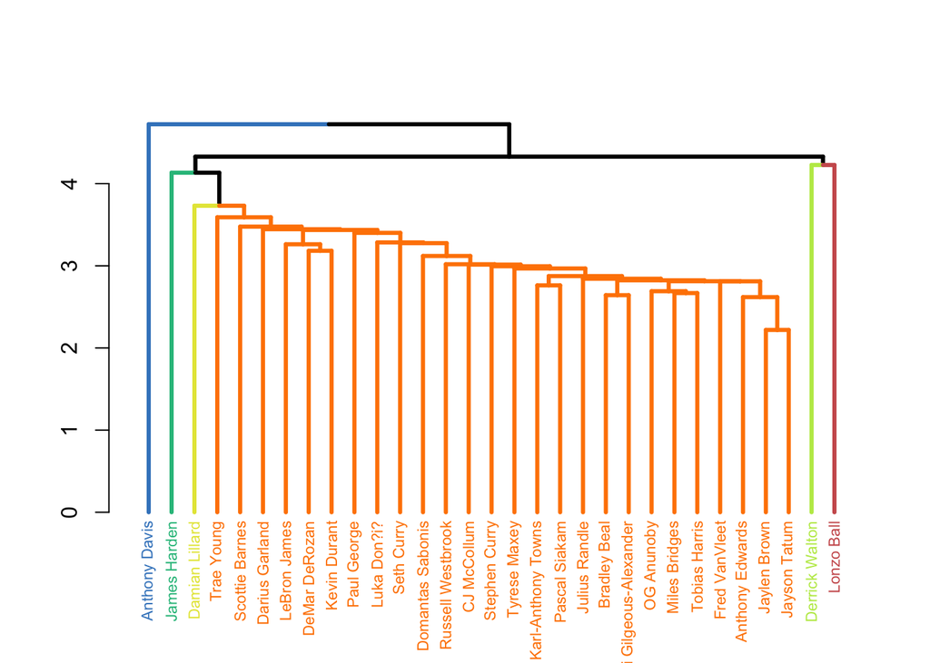

```r
# Hierarchical clustering (single linkage)
nba_player_hc_single <- hclust(nba_player_dist, method = "single" )

# converting to a dendrogram
nba_player_hc_single %>%
  as.dendrogram() -> nba_player_hc_dend_single # Store as dendrogram

# Visualizing the complete linkage dendrogram
nba_player_hc_dend_single %>%
  set("labels_col", value = c("#3d85c6", "#29be8a", "#e5e544","#ff8400","#bce954", "indianred"), k=6) %>%
  set("branches_k_color", value = c("#3d85c6", "#29be8a", "#e5e544","#ff8400","#bce954","indianred"), k = 6) %>%
  set("branches_lwd", 3) %>%
  set("labels_cex", 0.7) %>%
  plot(horiz=FALSE, axes=TRUE)
abline(v = 350, lty = 5)
```

**Figure 2b.** A single linkage dendrogram visualizing hierarchical agglomerative clustering based on euclidean distance measurements. The graphic shows clustering results for the top 30 players by average minutes played per game. Multivariate clusters are ordered by color. Six clusters are shown, but more a present. Y-axis represents distance and the x-axis represents player.

### Tanglegram

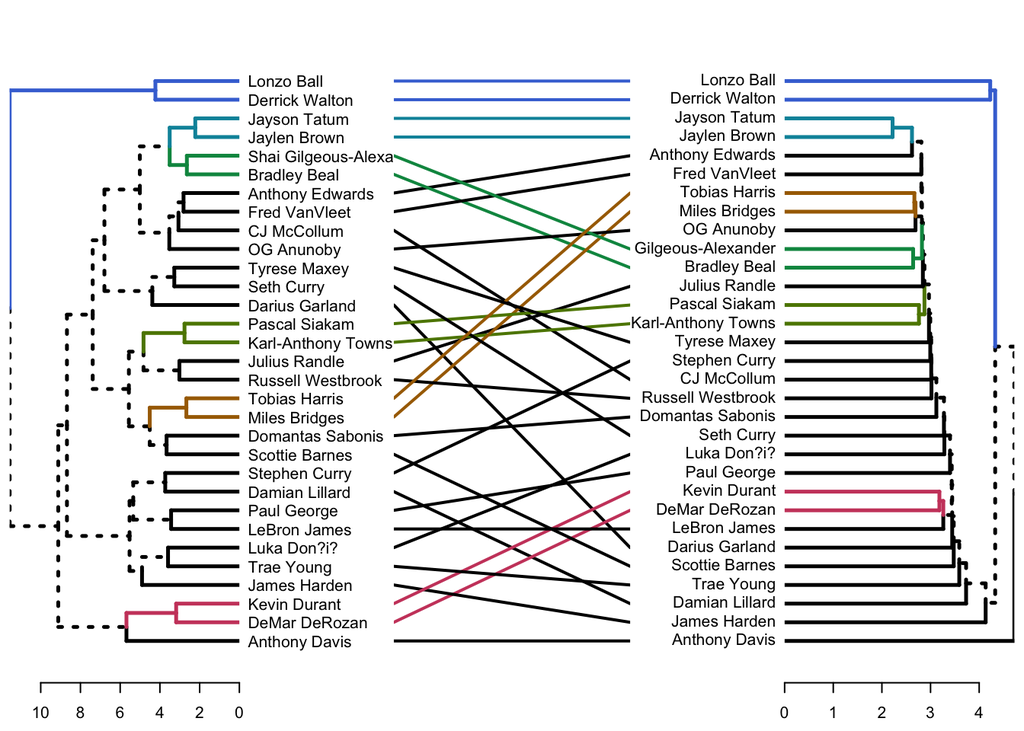

```r
# Convert to class dendrogram
dend_complete_p <- as.dendrogram(nba_player_hc_complete) # Complete linkage
dend_simple_p <- as.dendrogram(nba_player_hc_single) # Single linkage

# Align and plot two dendrograms side by side
dendlist(dend_complete_p, dend_simple_p) %>%
  untangle(method = "step1side") %>% # Find the best alignment layout
  tanglegram(common_subtrees_color_branches = TRUE, # Adjust the aesthetics
             lwd = 2.0, edge.lwd = 2.5,
             margin_inner = 8)
```

**Figure 2c.** A tanglegram visualizing the relationship between the complete linkage and single linkage dendrograms. Similar cluster results are tied together with lines. Strong clusters are emphasized with color.

```r
# Read in the 'water chemistry' data
nba_player_pts <- read_csv(here('data','nba.csv')) %>%
  clean_names() %>% # convert to lowercase
  select(-rk,-tm,-g,-gs,-pos,-fg_percent,-x3p_percent,-x2p_percent,-ft_percent,-e_fg_percent,-trb) %>%
  na_if(-999) %>%
  slice_max(order_by = pts, n = 30) %>%
  select(-mp)

# Create a summary dataframe
nba_player_pts_sum <- nba_player_pts %>%
  group_by(player) %>%
  summarize(age_mean = mean(age, na.rm = T),
            fg_mean = mean(fg, na.rm = T),
            fga_mean = mean(fga, na.rm = T),
            x3p_mean = mean(x3p, na.rm = T),
            x3pa_mean = mean(x3pa, na.rm = T),
            x2p_mean = mean(x2p, na.rm = T),
            x2pa_mean = mean(x2pa, na.rm = T),
            orb_mean = mean(orb, na.rm = T),
            ft_mean = mean(ft, na.rm = T),
            fta_mean = mean(fta, na.rm = T),
            drb_mean = mean(drb, na.rm = T),
            ast_mean = mean(ast, na.rm = T),
            stl_mean = mean(stl, na.rm = T),
            blk_mean = mean(blk, na.rm = T),
            tov_mean = mean(tov, na.rm = T),
            pf_mean = mean(pf, na.rm = T),
            pts_mean = mean(pts, na.rm = T))

nba_player_pts_scale <- nba_player_pts_sum %>%
  select(-player) %>%
  scale()

rownames(nba_player_pts_scale) <- nba_player_pts_sum$player
```

## Player Analysis (top 30 players by points per game)

The following analysis will use **hierarchical agglomerative clustering (HAC)** to determine clusters for the top 30 players in the NBA by average points per game. Clustering will be based on **euclidean distance** measurements. Both a complete linkage and single linkage dendrogram will be presented, as well as a subsequent tanglegram to compare the two.

### Complete Linkage Dendrogram

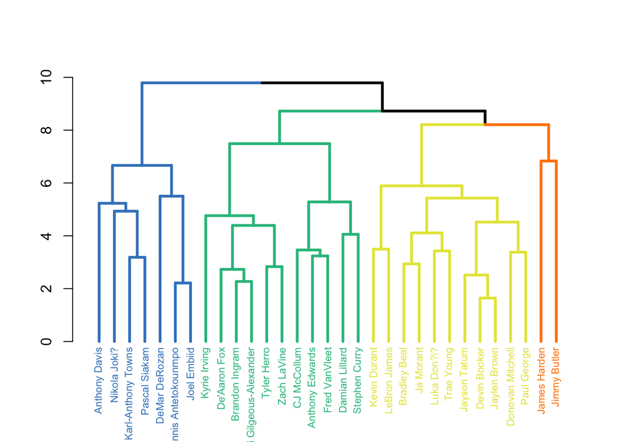

```r
# Calculating the Euclidian matrix
nba_player_pts_dist <- dist(nba_player_pts_scale, method = 'euclidean')

# Hierarchical clustering (complete linkage)
nba_player_pts_hc_complete <- hclust(nba_player_pts_dist, method = "complete")

# converting to a dendrogram
nba_player_pts_hc_complete %>%
  as.dendrogram() -> nba_player_pts_hc_dend_complete # Store as dendrogram

# Visualizing the complete linkage dendrogram
nba_player_pts_hc_dend_complete %>%
  set("labels_col", value = c("#3d85c6", "#29be8a", "#e5e544","#ff8400"), k=4) %>%
  set("branches_k_color", value = c("#3d85c6", "#29be8a", "#e5e544","#ff8400"), k = 4) %>%
  set("branches_lwd", 3) %>%
  set("labels_cex", 0.7) %>%
  plot(horiz=FALSE, axes=TRUE)
abline(v = 350, lty = 5)
```

### Single Linkage Dendrogram

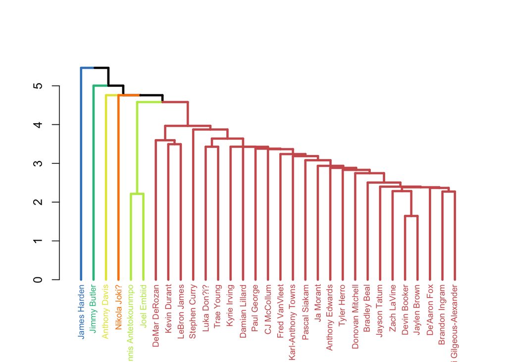

```r
# Hierarchical clustering (single linkage)
nba_player_pts_hc_single <- hclust(nba_player_pts_dist, method = "single" )

# converting to a dendrogram
nba_player_pts_hc_single %>%
  as.dendrogram() -> nba_player_pts_hc_dend_single # Store as dendrogram

# Visualizing the complete linkage dendrogram
nba_player_pts_hc_dend_single %>%
  set("labels_col", value = c("#3d85c6", "#29be8a", "#e5e544","#ff8400","#bce954", "indianred"), k=6) %>%
  set("branches_k_color", value = c("#3d85c6", "#29be8a", "#e5e544","#ff8400","#bce954","indianred"), k = 6) %>%
  set("branches_lwd", 3) %>%
  set("labels_cex", 0.7) %>%
  plot(horiz=FALSE, axes=TRUE)
abline(v = 350, lty = 5)
```

**Figure 3b.** A single linkage dendrogram visualizing hierarchical agglomerative clustering based on euclidean distance measurements. The graphic shows clustering results for the top 30 players average points scored per game. Multivariate clusters are ordered by color. Six clusters are shown, but more a present. Y-axis represents distance and the x-axis represents player.

### Tanglegram

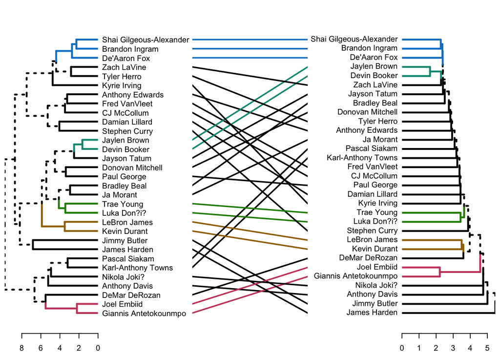

```r
# Convert to class dendrogram
dend_complete_p_pts <- as.dendrogram(nba_player_pts_hc_complete) # Complete linkage
dend_simple_p_pts <- as.dendrogram(nba_player_pts_hc_single) # Single linkage

# Align and plot two dendrograms side by side
dendlist(dend_complete_p_pts, dend_simple_p_pts) %>%
  untangle(method = "step1side") %>% # Find the best alignment layout
  tanglegram(common_subtrees_color_branches = TRUE, # Adjust the aesthetics
             lwd = 2.0, edge.lwd = 2.5,
             margin_inner = 10)
```

**Figure 3c.** A tanglegram visualizing the relationship between the complete linkage and single linkage dendrograms. Similar cluster results are tied together with lines. Strong clusters are emphasized with color.

### Analysis

The **hierarchical agglomerative clustering** produced some interesting observations. Given the complexity of finding similarities between diverse teams, it is hard to glean clear findings from the team analysis. In contrast, there are much clearer clusters in the player analysis.

At higher distances (~6) we can see larger trends such as high rebound players (cluster includes Joel Embiid, Giannis Antentokounmpo, Nikoa Jokic, etc.). Further research could include additional data on physical characteristics of players: height, wingspan, vertical jump height, etc.

#### Data Citation:

Basketball Reference. (n.d.). 2021-22 NBA player stats: Per game. Basketball Reference. Retrieved February 17, 2022, from https://www.basketball-reference.com/leagues/NBA_2022_per_game.html

Scraped by: Kaggle user Vivo Vinco